# EDA Danych dotyczących Titanica

## Wstęp

RMS Titanic był jednym z największych i najbardziej luksusowych statków swoich czasów. Należał do linii White Star Line i miał być symbolem nowoczesności oraz bezpieczeństwa. Wypłynął w swój dziewiczy rejs z Southampton (Wielka Brytania) do Nowego Jorku 10 kwietnia 1912 roku. Po drodze zawinął jeszcze do dwóch portów, gdzie na pokład wsiadali pasażerowie:

**Cherbourg** (Francja) – 10 kwietnia 1912, wieczorem. W Cherbourgu na pokład weszło 274 pasażerów, głównie z pierwszej i drugiej klasy.

**Queenstown** (Irlandia) – 11 kwietnia 1912. Na pokład wsiadło 120 pasażerów, głównie z trzeciej klasy. W Queenstown statek opuściło także 7 osób, w tym ojciec Francis Browne, który zrobił jedne z ostatnich zdjęć Titanica przed katastrofą.

[figure not shown]

„Pełną parą do…,” Titanic opuszczający Queenstown (Cobh), hrabstwo Cork, kwiecień 1912 Muzeum Sztuki Raclin Murphy, Uniwersytet Notre Dame http://www.jezuici.pl

Na pokładzie znajdowało się około **2200 pasażerów i załogi** – od bogatych arystokratów podróżujących w pierwszej klasie po imigrantów w trzeciej klasie, którzy liczyli na nowe życie w Ameryce.

14 kwietnia 1912 roku, o godzinie **23:40**, Titanic uderzył w górę lodową. Mimo że uznawano go za „niezatapialny”, statek zatonął w ciągu zaledwie 2 godzin i 40 minut, łamiąc się na pół. Katastrofa pochłonęła życie **ponad 1500 osób**, głównie z powodu braku wystarczającej liczby szalup ratunkowych. Ostatecznie **tylko 706 osób przeżyło**.

## Cel analizy

Katastrofa Titanica była jednym z najbardziej dramatycznych wydarzeń morskich w historii. Dzięki dostępnym danym możemy spojrzeć na tę historię z perspektywy analizy statystycznej i odpowiedzieć na pytanie: **jakie czynniki miały wpływ na szanse przeżycia pasażerów?**

### 1️ Identyfikacja czynników wpływających na przeżywalność

- Czy kobiety rzeczywiście miały większe szanse na przeżycie niż mężczyźni?
- Czy klasa biletu odgrywała istotną rolę w ratowaniu pasażerów?
- Czy wiek pasażerów miał znaczenie – czy dzieci były ratowane jako pierwsze?
- Czy podróżowanie z rodziną zwiększało szanse na przeżycie?

### 2️ Analiza demograficzna pasażerów

- Jak wyglądał rozkład wieku pasażerów?
- Skąd pochodziło najwięcej pasażerów?
- Ilu pasażerów podróżowało samotnie, a ilu z rodzinami?

### 3️ Analiza ekonomiczna podróży

- Jakie były ceny biletów w poszczególnych klasach?
- Czy droższy bilet oznaczał większe szanse na przeżycie?
- Jakie różnice istniały między pasażerami poszczególnych klas?

### 4 Analiza logistyczna tragedii

- Czy miejsce wejścia na pokład (Southampton, Cherbourg, Queenstown) miało wpływ na przeżywalność?
- Czy rozmieszczenie pasażerów na statku mogło wpłynąć na ich szanse na ratunek?

### 5️ Wizualizacja danych i interpretacja wyników

- Przedstawienie najważniejszych zależności za pomocą wykresów i tabel.
- Sprawdzenie, czy można przewidzieć, kto miał największe szanse na przeżycie.

## Dlaczego ta analiza jest ważna?

Chociaż od katastrofy Titanica minął ponad wiek, analiza danych pozwala nam nie tylko lepiej zrozumieć wydarzenia z przeszłości, ale także wyciągnąć wnioski na przyszłość.

Dzięki EDA możemy nie tylko sprawdzić, które cechy pasażerów miały wpływ na ich los, ale także zwizualizować te zależności w sposób czytelny i przystępny.

## O Danych

Kolumny:

- **pclass** - Klasa biletu
- **survived** - Czy pasażer przeżył katastrofę
- **name** - Imię i nazwisko pasażera
- **sex** - Płeć pasażera
- **age** - Wiek pasażera
- **sibsp** - Liczba rodzeństwa/małżonków na pokładzie
- **parch** - Liczba rodziców/dzieci na pokładzie
- **ticket** - Numer biletu
- **fare** - Cena biletu
- **cabin** - Numer kabiny
- **embarked** - Port, w którym pasażer wszedł na pokład
- **boat** - Numer łodzi ratunkowej
- **body** - Numer ciała (jeśli pasażer nie przeżył i ciało zostało odnalezione)
- **home.dest** - Miejsce docelowe

# EDA 1 - ogólna analiza danych

|  | pclass | survived | name | sex | age | sibsp | parch | ticket | fare | cabin | embarked | boat | body | home.dest |
| --- | --- | --- | --- | --- | --- | --- | --- | --- | --- | --- | --- | --- | --- | --- |
| 0 | 1.0 | 1.0 | Allen, Miss. Elisabeth Walton | female | 29.0000 | 0.0 | 0.0 | 24160 | 211.3375 | B5 | S | 2 | NaN | St Louis, MO |
| 1 | 1.0 | 1.0 | Allison, Master. Hudson Trevor | male | 0.9167 | 1.0 | 2.0 | 113781 | 151.5500 | C22 C26 | S | 11 | NaN | Montreal, PQ / Chesterville, ON |
| 2 | 1.0 | 0.0 | Allison, Miss. Helen Loraine | female | 2.0000 | 1.0 | 2.0 | 113781 | 151.5500 | C22 C26 | S | NaN | NaN | Montreal, PQ / Chesterville, ON |
| 3 | 1.0 | 0.0 | Allison, Mr. Hudson Joshua Creighton | male | 30.0000 | 1.0 | 2.0 | 113781 | 151.5500 | C22 C26 | S | NaN | 135.0 | Montreal, PQ / Chesterville, ON |
| 4 | 1.0 | 0.0 | Allison, Mrs. Hudson J C (Bessie Waldo Daniels) | female | 25.0000 | 1.0 | 2.0 | 113781 | 151.5500 | C22 C26 | S | NaN | NaN | Montreal, PQ / Chesterville, ON |
| ... | ... | ... | ... | ... | ... | ... | ... | ... | ... | ... | ... | ... | ... | ... |
| 1305 | 3.0 | 0.0 | Zabour, Miss. Thamine | female | NaN | 1.0 | 0.0 | 2665 | 14.4542 | NaN | C | NaN | NaN | NaN |
| 1306 | 3.0 | 0.0 | Zakarian, Mr. Mapriededer | male | 26.5000 | 0.0 | 0.0 | 2656 | 7.2250 | NaN | C | NaN | 304.0 | NaN |
| 1307 | 3.0 | 0.0 | Zakarian, Mr. Ortin | male | 27.0000 | 0.0 | 0.0 | 2670 | 7.2250 | NaN | C | NaN | NaN | NaN |
| 1308 | 3.0 | 0.0 | Zimmerman, Mr. Leo | male | 29.0000 | 0.0 | 0.0 | 315082 | 7.8750 | NaN | S | NaN | NaN | NaN |
| 1309 | NaN | NaN | NaN | NaN | NaN | NaN | NaN | NaN | NaN | NaN | NaN | NaN | NaN | NaN |

1310 rows × 14 columns

```
(1310, 14)
```

```
<class 'pandas.core.frame.DataFrame'>
RangeIndex: 1310 entries, 0 to 1309
Data columns (total 14 columns):
 #   Column     Non-Null Count  Dtype
---  ------     --------------  -----
 0   pclass     1309 non-null   float64
 1   survived   1309 non-null   float64
 2   name       1309 non-null   object
 3   sex        1309 non-null   object
 4   age        1046 non-null   float64
 5   sibsp      1309 non-null   float64
 6   parch      1309 non-null   float64
 7   ticket     1309 non-null   object
 8   fare       1308 non-null   float64
 9   cabin      295 non-null    object
 10  embarked   1307 non-null   object
 11  boat       486 non-null    object
 12  body       121 non-null    float64
 13  home.dest  745 non-null    object
dtypes: float64(7), object(7)
memory usage: 143.4+ KB
```

|  | pclass | survived | name | sex | age | sibsp | parch | ticket | fare | cabin | embarked | boat | body | home.dest | title |
| --- | --- | --- | --- | --- | --- | --- | --- | --- | --- | --- | --- | --- | --- | --- | --- |
| 0 | 1.0 | 1.0 | Allen, Miss. Elisabeth Walton | female | 29.0000 | 0.0 | 0.0 | 24160 | 211.3375 | B5 | S | 2 | NaN | St Louis, MO | Miss |
| 1 | 1.0 | 1.0 | Allison, Master. Hudson Trevor | male | 0.9167 | 1.0 | 2.0 | 113781 | 151.5500 | C22 C26 | S | 11 | NaN | Montreal, PQ / Chesterville, ON | Master |
| 2 | 1.0 | 0.0 | Allison, Miss. Helen Loraine | female | 2.0000 | 1.0 | 2.0 | 113781 | 151.5500 | C22 C26 | S | NaN | NaN | Montreal, PQ / Chesterville, ON | Miss |
| 3 | 1.0 | 0.0 | Allison, Mr. Hudson Joshua Creighton | male | 30.0000 | 1.0 | 2.0 | 113781 | 151.5500 | C22 C26 | S | NaN | 135.0 | Montreal, PQ / Chesterville, ON | Mr |
| 4 | 1.0 | 0.0 | Allison, Mrs. Hudson J C (Bessie Waldo Daniels) | female | 25.0000 | 1.0 | 2.0 | 113781 | 151.5500 | C22 C26 | S | NaN | NaN | Montreal, PQ / Chesterville, ON | Mrs |
| ... | ... | ... | ... | ... | ... | ... | ... | ... | ... | ... | ... | ... | ... | ... | ... |
| 1305 | 3.0 | 0.0 | Zabour, Miss. Thamine | female | NaN | 1.0 | 0.0 | 2665 | 14.4542 | NaN | C | NaN | NaN | NaN | Miss |
| 1306 | 3.0 | 0.0 | Zakarian, Mr. Mapriededer | male | 26.5000 | 0.0 | 0.0 | 2656 | 7.2250 | NaN | C | NaN | 304.0 | NaN | Mr |
| 1307 | 3.0 | 0.0 | Zakarian, Mr. Ortin | male | 27.0000 | 0.0 | 0.0 | 2670 | 7.2250 | NaN | C | NaN | NaN | NaN | Mr |
| 1308 | 3.0 | 0.0 | Zimmerman, Mr. Leo | male | 29.0000 | 0.0 | 0.0 | 315082 | 7.8750 | NaN | S | NaN | NaN | NaN | Mr |
| 1309 | NaN | NaN | NaN | NaN | NaN | NaN | NaN | NaN | NaN | NaN | NaN | NaN | NaN | NaN | NaN |

1310 rows × 15 columns

|  | name | title | sex | age | survived | sibsp | parch | body | pclass | cabin | fare | embarked | home.dest | boat | ticket |
| --- | --- | --- | --- | --- | --- | --- | --- | --- | --- | --- | --- | --- | --- | --- | --- |
| 0 | Allen, Miss. Elisabeth Walton | Miss | female | 29.0000 | 1.0 | 0.0 | 0.0 | NaN | 1.0 | B5 | 211.3375 | S | St Louis, MO | 2 | 24160 |
| 1 | Allison, Master. Hudson Trevor | Master | male | 0.9167 | 1.0 | 1.0 | 2.0 | NaN | 1.0 | C22 C26 | 151.5500 | S | Montreal, PQ / Chesterville, ON | 11 | 113781 |
| 2 | Allison, Miss. Helen Loraine | Miss | female | 2.0000 | 0.0 | 1.0 | 2.0 | NaN | 1.0 | C22 C26 | 151.5500 | S | Montreal, PQ / Chesterville, ON | NaN | 113781 |
| 3 | Allison, Mr. Hudson Joshua Creighton | Mr | male | 30.0000 | 0.0 | 1.0 | 2.0 | 135.0 | 1.0 | C22 C26 | 151.5500 | S | Montreal, PQ / Chesterville, ON | NaN | 113781 |
| 4 | Allison, Mrs. Hudson J C (Bessie Waldo Daniels) | Mrs | female | 25.0000 | 0.0 | 1.0 | 2.0 | NaN | 1.0 | C22 C26 | 151.5500 | S | Montreal, PQ / Chesterville, ON | NaN | 113781 |
| ... | ... | ... | ... | ... | ... | ... | ... | ... | ... | ... | ... | ... | ... | ... | ... |
| 1305 | Zabour, Miss. Thamine | Miss | female | NaN | 0.0 | 1.0 | 0.0 | NaN | 3.0 | NaN | 14.4542 | C | NaN | NaN | 2665 |
| 1306 | Zakarian, Mr. Mapriededer | Mr | male | 26.5000 | 0.0 | 0.0 | 0.0 | 304.0 | 3.0 | NaN | 7.2250 | C | NaN | NaN | 2656 |
| 1307 | Zakarian, Mr. Ortin | Mr | male | 27.0000 | 0.0 | 0.0 | 0.0 | NaN | 3.0 | NaN | 7.2250 | C | NaN | NaN | 2670 |
| 1308 | Zimmerman, Mr. Leo | Mr | male | 29.0000 | 0.0 | 0.0 | 0.0 | NaN | 3.0 | NaN | 7.8750 | S | NaN | NaN | 315082 |
| 1309 | NaN | NaN | NaN | NaN | NaN | NaN | NaN | NaN | NaN | NaN | NaN | NaN | NaN | NaN | NaN |

1310 rows × 15 columns

|  | name | title | sex | age | survived | sibsp | parch | body | pclass | cabin | fare | embarked | home.dest | boat | ticket |
| --- | --- | --- | --- | --- | --- | --- | --- | --- | --- | --- | --- | --- | --- | --- | --- |
| 0 | Allen, Miss. Elisabeth Walton | Miss | female | 29.0000 | 1.0 | 0.0 | 0.0 | NaN | 1.0 | B5 | 211.3375 | S | St Louis, MO | 2 | 24160 |
| 1 | Allison, Master. Hudson Trevor | Master | male | 0.9167 | 1.0 | 1.0 | 2.0 | NaN | 1.0 | C22 C26 | 151.5500 | S | Montreal, PQ / Chesterville, ON | 11 | 113781 |
| 2 | Allison, Miss. Helen Loraine | Miss | female | 2.0000 | 0.0 | 1.0 | 2.0 | NaN | 1.0 | C22 C26 | 151.5500 | S | Montreal, PQ / Chesterville, ON | NaN | 113781 |
| 3 | Allison, Mr. Hudson Joshua Creighton | Mr | male | 30.0000 | 0.0 | 1.0 | 2.0 | 135.0 | 1.0 | C22 C26 | 151.5500 | S | Montreal, PQ / Chesterville, ON | NaN | 113781 |
| 4 | Allison, Mrs. Hudson J C (Bessie Waldo Daniels) | Mrs | female | 25.0000 | 0.0 | 1.0 | 2.0 | NaN | 1.0 | C22 C26 | 151.5500 | S | Montreal, PQ / Chesterville, ON | NaN | 113781 |

|  | name | title | sex | age | survived | sibsp | parch | body | pclass | cabin | fare | embarked | home.dest | boat | ticket |
| --- | --- | --- | --- | --- | --- | --- | --- | --- | --- | --- | --- | --- | --- | --- | --- |
| 1305 | Zabour, Miss. Thamine | Miss | female | NaN | 0.0 | 1.0 | 0.0 | NaN | 3.0 | NaN | 14.4542 | C | NaN | NaN | 2665 |
| 1306 | Zakarian, Mr. Mapriededer | Mr | male | 26.5 | 0.0 | 0.0 | 0.0 | 304.0 | 3.0 | NaN | 7.2250 | C | NaN | NaN | 2656 |
| 1307 | Zakarian, Mr. Ortin | Mr | male | 27.0 | 0.0 | 0.0 | 0.0 | NaN | 3.0 | NaN | 7.2250 | C | NaN | NaN | 2670 |
| 1308 | Zimmerman, Mr. Leo | Mr | male | 29.0 | 0.0 | 0.0 | 0.0 | NaN | 3.0 | NaN | 7.8750 | S | NaN | NaN | 315082 |
| 1309 | NaN | NaN | NaN | NaN | NaN | NaN | NaN | NaN | NaN | NaN | NaN | NaN | NaN | NaN | NaN |

|  | name | title | sex | age | survived | sibsp | parch | body | pclass | cabin | fare | embarked | home.dest | boat | ticket |
| --- | --- | --- | --- | --- | --- | --- | --- | --- | --- | --- | --- | --- | --- | --- | --- |
| 1304 | Zabour, Miss. Hileni | Miss | female | 14.5 | 0.0 | 1.0 | 0.0 | 328.0 | 3.0 | NaN | 14.4542 | C | NaN | NaN | 2665 |
| 1305 | Zabour, Miss. Thamine | Miss | female | NaN | 0.0 | 1.0 | 0.0 | NaN | 3.0 | NaN | 14.4542 | C | NaN | NaN | 2665 |
| 1306 | Zakarian, Mr. Mapriededer | Mr | male | 26.5 | 0.0 | 0.0 | 0.0 | 304.0 | 3.0 | NaN | 7.2250 | C | NaN | NaN | 2656 |
| 1307 | Zakarian, Mr. Ortin | Mr | male | 27.0 | 0.0 | 0.0 | 0.0 | NaN | 3.0 | NaN | 7.2250 | C | NaN | NaN | 2670 |
| 1308 | Zimmerman, Mr. Leo | Mr | male | 29.0 | 0.0 | 0.0 | 0.0 | NaN | 3.0 | NaN | 7.8750 | S | NaN | NaN | 315082 |

|  | name | title | sex | age | survived | sibsp | parch | body | pclass | cabin | fare | embarked | home.dest | boat | ticket |
| --- | --- | --- | --- | --- | --- | --- | --- | --- | --- | --- | --- | --- | --- | --- | --- |
| 1244 | Thomas, Mrs. Alexander (Thamine "Thelma") | Mrs | female | 16.0000 | 1.0 | 1.0 | 1.0 | NaN | 3.0 | NaN | 8.5167 | C | NaN | 14 | 2625 |
| 798 | Finoli, Mr. Luigi | Mr | male | NaN | 1.0 | 0.0 | 0.0 | NaN | 3.0 | NaN | 7.0500 | S | Italy Philadelphia, PA | 15 | SOTON/O.Q. 3101308 |
| 437 | Herman, Miss. Alice | Miss | female | 24.0000 | 1.0 | 1.0 | 2.0 | NaN | 2.0 | NaN | 65.0000 | S | Somerset / Bernardsville, NJ | 9 | 220845 |
| 84 | Cumings, Mr. John Bradley | Mr | male | 39.0000 | 0.0 | 1.0 | 0.0 | NaN | 1.0 | C85 | 71.2833 | C | New York, NY | NaN | PC 17599 |
| 1307 | Zakarian, Mr. Ortin | Mr | male | 27.0000 | 0.0 | 0.0 | 0.0 | NaN | 3.0 | NaN | 7.2250 | C | NaN | NaN | 2670 |
| 266 | Smart, Mr. John Montgomery | Mr | male | 56.0000 | 0.0 | 0.0 | 0.0 | NaN | 1.0 | NaN | 26.5500 | S | New York, NY | NaN | 113792 |
| 590 | West, Miss. Barbara J | Miss | female | 0.9167 | 1.0 | 1.0 | 2.0 | NaN | 2.0 | NaN | 27.7500 | S | Bournmouth, England | 10 | C.A. 34651 |
| 1094 | Osman, Mrs. Mara | Mrs | female | 31.0000 | 1.0 | 0.0 | 0.0 | NaN | 3.0 | NaN | 8.6833 | S | NaN | NaN | 349244 |
| 1009 | McMahon, Mr. Martin | Mr | male | NaN | 0.0 | 0.0 | 0.0 | NaN | 3.0 | NaN | 7.7500 | Q | NaN | NaN | 370372 |
| 1078 | O'Dwyer, Miss. Ellen "Nellie" | Miss | female | NaN | 1.0 | 0.0 | 0.0 | NaN | 3.0 | NaN | 7.8792 | Q | NaN | NaN | 330959 |

```
0
```

```
name         1307
title          18
sex             2
age            98
survived        2
sibsp           7
parch           8
body          121
pclass          3
cabin         186
fare          281
embarked        3
home.dest     369
boat           27
ticket        929
dtype: int64
```

# EDA2 - analiza brakujacych wartości

|  | index | Ilość |
| --- | --- | --- |
| 0 | name | 0 |
| 1 | title | 0 |
| 2 | sex | 0 |
| 3 | age | 263 |
| 4 | survived | 0 |
| 5 | sibsp | 0 |
| 6 | parch | 0 |
| 7 | body | 1188 |
| 8 | pclass | 0 |
| 9 | cabin | 1014 |
| 10 | fare | 1 |
| 11 | embarked | 2 |
| 12 | home.dest | 564 |
| 13 | boat | 823 |
| 14 | ticket | 0 |

##### W zbiorze danych występują brakujące wartości w następujących kolumnach:

**age** – brakujące dane dla 263 pasażerów, co stanowi około 20% wszystkich obserwacji. Możliwe, że brak wieku może wynikać z niepełnych zapisów podczas rejestracji pasażerów.

**body** – brakujące dane dla 1188 pasażerów, ponieważ tylko pasażerowie, którzy nie przeżyli katastrofy, mieli przypisany numer ciała. Pasażerowie, którzy przeżyli, nie mają tych informacji. Ewentualnie ciało nie zostało odnalezione lub nie nadano numeru.

**cabin** – brakujące dane dla 1014 pasażerów. Wiele osób podróżowało w trzeciej klasie, gdzie nie było przypisanych kabin, lub dane te zostały po prostu pominięte.

**fare** – brakujące dane dla 1 pasażera. Brak jednej wartości w tej kolumnie sugeruje, że jest to rzadki przypadek, który nie wpłynie znacząco na analizę. Pasażer mógł być zwolniony z opłaty lub zapis mógł być błędny.

**embarked** – brakujące dane dla 2 pasażerów. Dwa brakujące wpisy są niewielką liczbą w stosunku do całości danych. Pasażerowie mogli mieć nietypowy lub niestandardowy sposób zaokrętowania, a brakujące dane mogą wynikać z błędów w rejestrze.

**home.dest** – brakujące dane dla 564 pasażerów. Jest to znaczna część danych. Może to wynikać z niepełnych zapisów pasażerskich lub faktu, że niektóre osoby nie miały jasno określonego celu podróży (np. emigranci szukający nowego życia). Duża liczba braków sprawia, że bezpośrednie usunięcie tych wierszy nie jest dobrą opcją, ponieważ moglibyśmy utracić cenne informacje o tych pasażerach w innych kolumnach. Wydaje się, że home.dest nie jest kluczową zmienną w analizie, można pozostawić wartości NaN. Dla ułatwienia interpretacji danych zamiast NaN przypiszemy "Brak informacji",

**boat** – Kolumna boat odnosi się do numerów łodzi ratunkowych, do których pasażerowie zostali przypisani lub do których udało im się wejść. Brakujące dane dla 823 pasażerów, czyli około 60% danych w tej kolumnie. To dość duża liczba, braki mogą wynikać z tego, że nie wszyscy pasażerowie dotarli do łodzi ratunkowych lub nie zapisano ich w rejestrze. Wielu pasażerów nie przeżyło katastrofy lub po prostu nie zostało przypisanych do żadnej łodzi ratunkowej, co może wyjaśniać brak tej informacji.

# EDA3 - transformacja danych

Po przeprowadzeniu ogólnej analizy danych oraz identyfikacji brakujących wartości, kolejnym krokiem będzie transformacja danych. Jej celem jest przygotowanie zbioru do dalszej analizy, eliminacja problemów wynikających z niespójności danych oraz poprawa ich jakości.

Transformacja danych w przypadku zbioru Titanica jest kluczowa, ponieważ brakujące wartości w niektórych kolumnach mogą prowadzić do błędnej interpretacji wyników, dlatego należy je odpowiednio uzupełnić lub usunąć.

Dzięki odpowiedniej transformacji dane będą bardziej jednorodne i gotowe do głębszej analizy, w tym do identyfikacji zależności między zmiennymi.

```
count    1046.000000
mean       29.881135
std        14.413500
min         0.166700
25%        21.000000
50%        28.000000
75%        39.000000
max        80.000000
Name: age, dtype: float64
```

Średnia wieku to ok. 30 lat, mediana wynosi 28 lat. Brakujące dane zostaną uzupełnione medianą. Wiek na Titanicu nie był skrajnie zróżnicowany, co oznacza, że imputacja brakujących danych o wiek za pomocą mediany nie będzie wprowadzała dużych zniekształceń w rozkładzie. Mediana będzie bardziej reprezentatywna niż średnia, ponieważ nie jest wrażliwa na skrajne wartości.

Wartość NaN w kolumnie body niesie ze sobą znaczenie, dlatego zamiast ją usuwać czy ignorować, przekształcimy ją w bardziej czytelną kategorię body_status a wartości NaN opiszemy jako "Brak numeru (przeżył lub nieodnaleziony)".

NaN w kolumnie cabin oznacza brak przypisania kabiny lub brak danych - zmieniamy na 'Nieprzydzielona'

Wartość Nan w kolumnie fare występuje tylko raz, uzupełnimy ją medianą

W kolumnie embarked brakuje danych dla 2 osób, uzupełniamy informacje najczęściej występującym portem zaokrętowania.

W kolumnie boat NaN oznacza brak przypisanej łodzi ratunkowej. Zamieniamy na "Brak informacji (nie przypisano łodzi)".

Ostatnia zmiana dotyczy kolumny home.dest gdzie NaN = brak celu podróży – nie został podany. Dla większej czytelności zmieniamy na "Nieznany".

|  | index | Ilość |
| --- | --- | --- |
| 0 | name | 0 |
| 1 | title | 0 |
| 2 | sex | 0 |
| 3 | age | 0 |
| 4 | survived | 0 |
| 5 | sibsp | 0 |
| 6 | parch | 0 |
| 7 | body | 1188 |
| 8 | pclass | 0 |
| 9 | cabin | 0 |
| 10 | fare | 0 |
| 11 | embarked | 0 |
| 12 | home.dest | 0 |
| 13 | boat | 0 |
| 14 | ticket | 0 |
| 15 | body_status | 0 |

# EDA4 - analiza pojedynczych zmiennych

|  | name | title | sex | age | survived | sibsp | parch | body | pclass | cabin | fare | embarked | home.dest | boat | ticket | body_status |
| --- | --- | --- | --- | --- | --- | --- | --- | --- | --- | --- | --- | --- | --- | --- | --- | --- |
| 0 | Allen, Miss. Elisabeth Walton | Miss | female | 29.0000 | 1.0 | 0.0 | 0.0 | NaN | 1.0 | B5 | 211.3375 | S | St Louis, MO | 2 | 24160 | Brak numeru (przeżył lub nieodnaleziony) |
| 1 | Allison, Master. Hudson Trevor | Master | male | 0.9167 | 1.0 | 1.0 | 2.0 | NaN | 1.0 | C22 C26 | 151.5500 | S | Montreal, PQ / Chesterville, ON | 11 | 113781 | Brak numeru (przeżył lub nieodnaleziony) |
| 2 | Allison, Miss. Helen Loraine | Miss | female | 2.0000 | 0.0 | 1.0 | 2.0 | NaN | 1.0 | C22 C26 | 151.5500 | S | Montreal, PQ / Chesterville, ON | Brak informacji (nie przypisano łodzi) | 113781 | Brak numeru (przeżył lub nieodnaleziony) |
| 3 | Allison, Mr. Hudson Joshua Creighton | Mr | male | 30.0000 | 0.0 | 1.0 | 2.0 | 135.0 | 1.0 | C22 C26 | 151.5500 | S | Montreal, PQ / Chesterville, ON | Brak informacji (nie przypisano łodzi) | 113781 | 135.0 |
| 4 | Allison, Mrs. Hudson J C (Bessie Waldo Daniels) | Mrs | female | 25.0000 | 0.0 | 1.0 | 2.0 | NaN | 1.0 | C22 C26 | 151.5500 | S | Montreal, PQ / Chesterville, ON | Brak informacji (nie przypisano łodzi) | 113781 | Brak numeru (przeżył lub nieodnaleziony) |
| ... | ... | ... | ... | ... | ... | ... | ... | ... | ... | ... | ... | ... | ... | ... | ... | ... |
| 1304 | Zabour, Miss. Hileni | Miss | female | 14.5000 | 0.0 | 1.0 | 0.0 | 328.0 | 3.0 | Nieprzydzielona | 14.4542 | C | Nieznany | Brak informacji (nie przypisano łodzi) | 2665 | 328.0 |
| 1305 | Zabour, Miss. Thamine | Miss | female | 28.0000 | 0.0 | 1.0 | 0.0 | NaN | 3.0 | Nieprzydzielona | 14.4542 | C | Nieznany | Brak informacji (nie przypisano łodzi) | 2665 | Brak numeru (przeżył lub nieodnaleziony) |
| 1306 | Zakarian, Mr. Mapriededer | Mr | male | 26.5000 | 0.0 | 0.0 | 0.0 | 304.0 | 3.0 | Nieprzydzielona | 7.2250 | C | Nieznany | Brak informacji (nie przypisano łodzi) | 2656 | 304.0 |
| 1307 | Zakarian, Mr. Ortin | Mr | male | 27.0000 | 0.0 | 0.0 | 0.0 | NaN | 3.0 | Nieprzydzielona | 7.2250 | C | Nieznany | Brak informacji (nie przypisano łodzi) | 2670 | Brak numeru (przeżył lub nieodnaleziony) |
| 1308 | Zimmerman, Mr. Leo | Mr | male | 29.0000 | 0.0 | 0.0 | 0.0 | NaN | 3.0 | Nieprzydzielona | 7.8750 | S | Nieznany | Brak informacji (nie przypisano łodzi) | 315082 | Brak numeru (przeżył lub nieodnaleziony) |

1309 rows × 16 columns

### Imię i nazwisko (name, title)

Oprócz imienia i nazwiska kolumna zawiera skróty / tytuły, które oznaczają formy grzecznościowe lub tytuły używane w krajach, z których pochodzili pasażerowie Titanica. Zostały wyodrębnione w oddzielnej kolumnie w celu dodatkowej analizy

```
array(['Miss', 'Master', 'Mr', 'Mrs', 'Col', 'Mme', 'Dr', 'Major', 'Capt',
       'Lady', 'Sir', 'Mlle', 'Dona', 'Jonkheer', 'the Countess', 'Don',
       'Rev', 'Ms'], dtype=object)
```

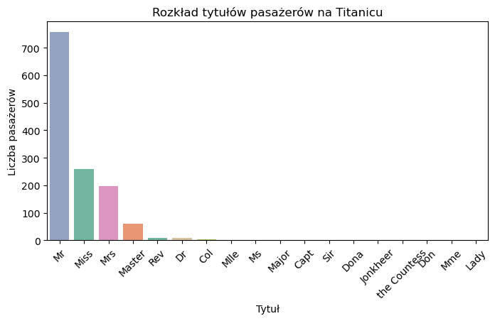

Najczęściej występujące tytuły:

"Mr" (Pan) – najliczniejsza grupa, co wskazuje na dużą liczbę dorosłych mężczyzn.

"Miss" (Panna) i "Mrs" (Pani) – dominują wśród kobiet.

"Master" – odnosi się do chłopców (niepełnoletnich mężczyzn).

Tytuły wojskowe i szlacheckie:

"Col", "Major", "Capt" – tytuły wojskowe, oznaczające pasażerów wysokiej rangi.

"Dr" – doktor (medycyny lub akademicki)

"Sir", "Lady", "the Countess" – tytuły arystokratyczne, pojawiające się rzadko.

Tytuły zagraniczne i nietypowe:

"Mme", "Mlle" – francuskie odpowiedniki „Pani” i „Panny”.

"Don", "Dona" – hiszpańskie tytuły szlacheckie.

"Jonkheer" – niderlandzki tytuł szlachecki.

Dla poprawienia czytelności wykresu i ułatwienia dalszej analizy dokonamy pewnych transformacji

Część tytłów saclimy (np. "Mme" → "Mrs", "Mlle" → "Miss"), a tytuły wojskowe i arystokratyczne połączymy w kategorię „Elita” dla lepszej analizy.

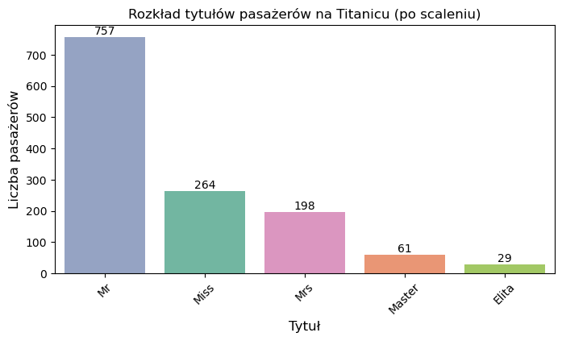

"Mr" nadal dominuje – większość pasażerów to mężczyźni, co pokazuje, że na pokładzie było znacznie więcej dorosłych mężczyzn niż innych grup.

"Miss" i "Mrs" to główne grupy wśród kobiet – połączenie Mme → Mrs oraz Mlle, Ms → Miss nie zmieniło ich dominacji.

"Master" to jedyny tytuł dla chłopców – potwierdza podział na dzieci i dorosłych.

"Elita" to mała, ale znacząca grupa – składa się z arystokratów, wojskowych i duchownych. Ich liczba jest niewielka, ale warto sprawdzić ich przeżywalność.

### Płeć pasażera (sex)

```
array(['female', 'male'], dtype=object)
```

**male** - mężczyzna,

**female** - kobieta

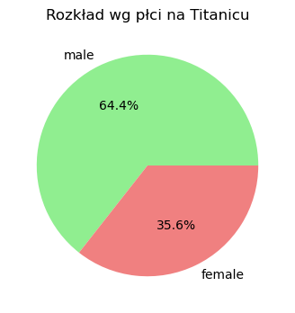

Na pokładzie Titanica dominowali mężczyźni, stanowili oni 64,4 % pasażerów.

Kobiety stanowiły 35,6 % pasażerów.

### Wiek pasażera (age)

```
Średnia wieku pasażerów: 30.0
Wiek najmłodszego pasażera: 0.1667
Wiek najstarszego pasażera: 80.0
```

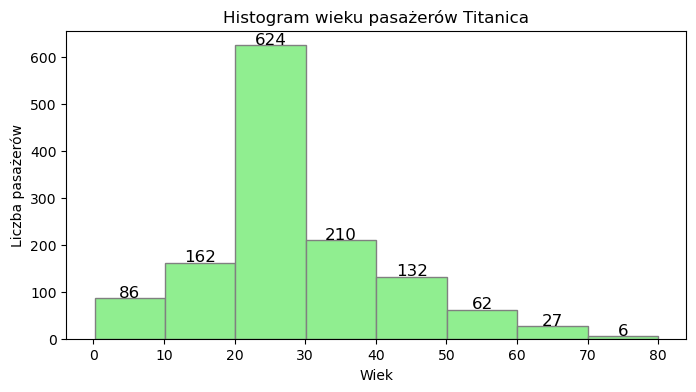

Na Titanicu wiek pasażerów nie był skrajnie zróżnicowany. Większość pasażerów to dorośli, a liczba dzieci i osób starszych była stosunkowo mniejsza. Największą grupą pasażerów były osoby w wieku między 20-30 lat - ponad 600 osób.

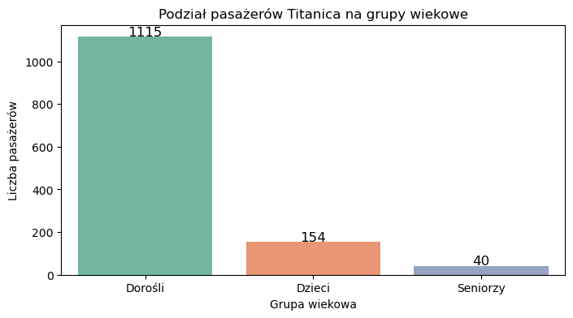

**Rozkład wieku na Titanicu:**

Większość pasażerów to byli dorośli, z przewagą osób w przedziale wiekowym 20-50 lat. Wiek średni pasażerów wynosił około 30 lat.

Na pokładzie Titanica były również dzieci, ale ich liczba stanowiła mniejszość.

Wśród pasażerów byli także seniorzy, jednak ich liczba była również niewielka w porównaniu z dorosłymi pasażerami.

### Czy pasażer przeżył katastrofę? (survived)

```
array([1., 0.])
```

**1** - przeżył

**0** - nie przeżył,

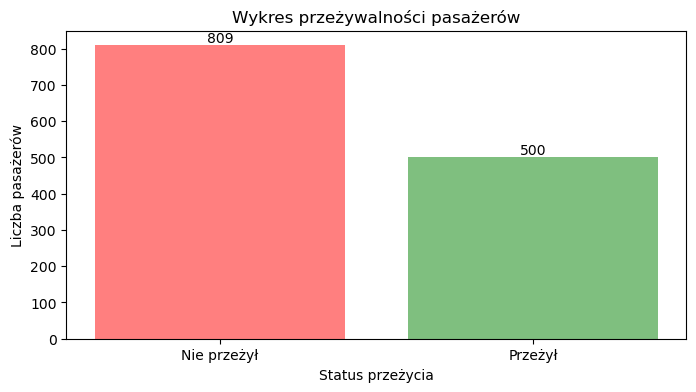

**Na 1309 osób przeżyło 500, co stanowi około 40% (38,17%) pasażerów. Większość pasażerów zginęła.**

### Ilu pasażerów podróżowało samotnie, a ilu z rodzinami? (sibsp, parch)

##### Liczba rodzeństwa/małżonków na pokładzie (sibsp)

##### Liczba rodziców/dzieci na pokładzie (parch)

Przykładowa interpretacja dla **sibsp** i **parch**

| Passenger | sibsp | parch | Znaczenie |
| --- | --- | --- | --- |
| Jan Kowalski | 0 | 0 | Podróżował samotnie, bez rodziny. |
| Anna Nowak | 1 | 0 | Miała na pokładzie męża/żonę lub jedno rodzeństwo. |
| Piotr Wiśniewski | 0 | 2 | Podróżował z dwójką rodziców. |
| Maria Lewandowska | 2 | 3 | Była na pokładzie z dwójką rodzeństwa/małżonkiem oraz trójką dzieci/rodziców. |

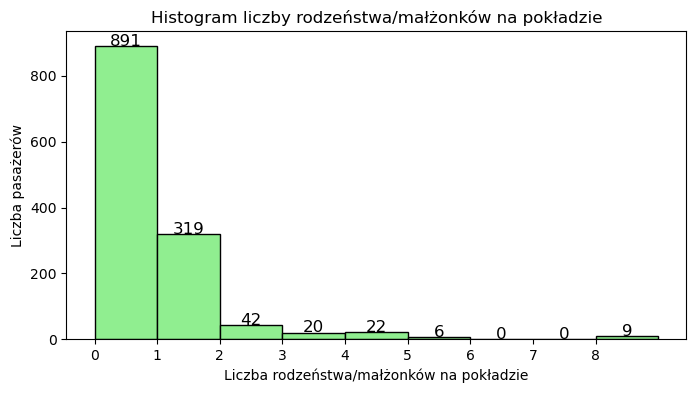

Jak widać większość pasażerów podróżowała samotnie – najczęstsza wartość na histogramie to 0, co oznacza, że duża liczba osób nie miała na pokładzie ani rodzeństwa, ani małżonka.

Kilkadziesiąt osób podróżowało z większą rodziną – występują wartości powyżej 1, co wskazuje, że część pasażerów podróżowała w grupach rodzinnych, choć były to raczej wyjątki.

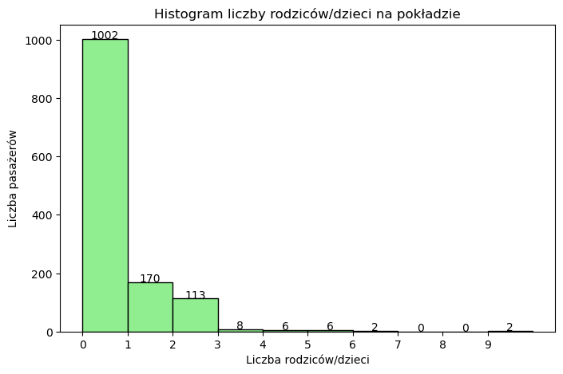

Największa częstotliwość występuje przy wartości 0, co oznacza, że większość osób nie miała na pokładzie ani rodziców, ani dzieci.

Mała liczba pasażerów podróżowała z większą rodziną – wartości powyżej 1 są znacznie rzadsze, co sugeruje, że osoby podróżujące z dziećmi lub rodzicami stanowiły mniejszość.

Podobny trend jak w przypadku rodzeństwa/małżonków.

### Numer ciała (body)

Jeśli pasażer nie przeżył, a jego ciało zostało odnalezione, otrzymał numer identyfikacyjny.

```
array([ nan, 135.,  22., 124., 148., 208., 172., 269.,  62., 133., 275.,
       147., 110., 307.,  38.,  80.,  45., 258., 126., 292., 175., 249.,
       230., 122., 263., 234., 189., 166., 207., 232.,  16., 109.,  96.,
        46., 245., 169., 174.,  97.,  18., 130.,  17., 295., 286., 236.,
       322., 297., 155., 305.,  19.,  75.,  35., 256., 149., 283., 165.,
       108., 121.,  52., 209., 271.,  43.,  15., 101., 287.,  81., 294.,
       293., 190.,  72., 103.,  79., 259., 260., 142., 299., 171.,   9.,
       197.,  51., 187.,  68.,  47.,  98., 188.,  69., 306., 120., 143.,
       156., 285.,  37.,  58.,  70., 196., 153.,  61.,  53., 201., 309.,
       181., 173.,  89.,   4., 206., 327., 119.,   7.,  32.,  67., 284.,
       261., 176.,  50.,   1., 255., 298., 314.,  14., 131., 312., 328.,
       304.])
```

```
Liczba odnalezionych ciał: 121
Liczba osób, których ciał nie odnaleziono: 1188
```

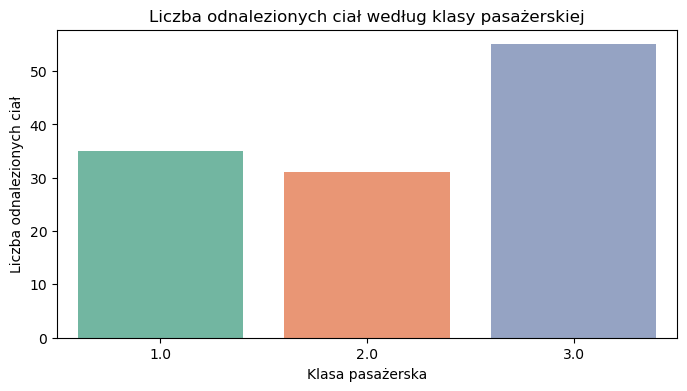

Widać, że trzecia klasa miała największą liczbę odnalezionych ciał. W porównaniu do innych klas, odsetek ofiar w 3 klasie był najwyższy, stąd też największa liczba ciał pasażerów 3 klasy.

Pierwsza i druga klasa miały zdecydowanie mniejszą liczbę odnalezionych ciał. W porównaniu do 3 klasy, liczba ofiar w tych klasach była znacznie niższa, co może świadczyć o wyższym poziomie bezpieczeństwa i łatwiejszym dostępie do ewakuacji dla pasażerów tych klas.

### Klasa biletu (pclass)

```
array([1., 2., 3.])
```

Na Titanicu istniały trzy klasy biletów, które odzwierciedlały status społeczny pasażerów oraz warunki podróży.

| pclass | Opis | Koszt biletu | Lokalizacja na statku |
| --- | --- | --- | --- |
| 1 | Pierwsza klasa | najdroższe | Górne pokłady (A, B, C) |
| 2 | Druga klasa | średnie | Środkowe pokłady (D, E) |
| 3 | Trzecia klasa | najtańsze | Dolne pokłady (F, G) |

**Pierwsza klasa** (pclass = 1)

- Luksusowe apartamenty i prywatne kabiny.
- Bogaci pasażerowie: przemysłowcy, politycy, celebryci.
- Dostęp do ekskluzywnych jadalni, sal balowych, bibliotek i siłowni.
- Największe szanse na przeżycie – znajdowali się bliżej pokładów ratunkowych.

**Cena biletu**: od 30 funtów do ponad 800 funtów (w przeliczeniu na dzisiejsze pieniądze to kilkadziesiąt tysięcy dolarów!).

**Druga klasa** (pclass = 2)

- Komfortowe kabiny, ale mniej luksusowe niż w pierwszej klasie.
- Przewożeni głównie średnia klasa społeczna, m.in. nauczyciele, lekarze, duchowni.
- Posiadali własne jadalnie, ale mniej ekskluzywne niż w pierwszej klasie.
- Szanse na przeżycie były średnie – znajdowali się na środkowych pokładach.

**Cena biletu**: ok. 13 funtów (ok. 1 500 dolarów dzisiaj).

**Trzecia klasa** (pclass = 3)

- Największa grupa pasażerów – głównie emigranci (z Irlandii, Skandynawii, Europy Wschodniej).
- Kabiny były ciasne, wieloosobowe, często dzielone z obcymi osobami.
- Znajdowali się w najniższej części statku, co utrudniało dostęp do szalup ratunkowych.
- Najmniejsze szanse na przeżycie – wiele osób zostało uwięzionych, gdy statek tonął.

**Cena biletu**: od 7 funtów (ok. 800 dolarów dzisiaj).

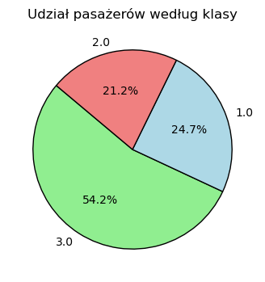

Najwięcej pasażerów podróżowało w 3 klasie – Prawdopodobnie większość pasażerów stanowili osoby z niższych warstw społecznych, co zgadza się z historycznymi danymi o Titanicu.

Dysproporcja między klasami – widać wyraźnie, że Titanic przewoził głównie osoby z 3 klasy.

### Numer kabiny (cabin)

```
array(['B5', 'C22 C26', 'E12', 'D7', 'A36', 'C101', nan, 'C62 C64', 'B35',
       'A23', 'B58 B60', 'D15', 'C6', 'D35', 'C148', 'C97', 'B49', 'C99',
       'C52', 'T', 'A31', 'C7', 'C103', 'D22', 'E33', 'A21', 'B10', 'B4',
       'E40', 'B38', 'E24', 'B51 B53 B55', 'B96 B98', 'C46', 'E31', 'E8',
       'B61', 'B77', 'A9', 'C89', 'A14', 'E58', 'E49', 'E52', 'E45',
       'B22', 'B26', 'C85', 'E17', 'B71', 'B20', 'A34', 'C86', 'A16',
       'A20', 'A18', 'C54', 'C45', 'D20', 'A29', 'C95', 'E25', 'C111',
       'C23 C25 C27', 'E36', 'D34', 'D40', 'B39', 'B41', 'B102', 'C123',
       'E63', 'C130', 'B86', 'C92', 'A5', 'C51', 'B42', 'C91', 'C125',
       'D10 D12', 'B82 B84', 'E50', 'D33', 'C83', 'B94', 'D49', 'D45',
       'B69', 'B11', 'E46', 'C39', 'B18', 'D11', 'C93', 'B28', 'C49',
       'B52 B54 B56', 'E60', 'C132', 'B37', 'D21', 'D19', 'C124', 'D17',
       'B101', 'D28', 'D6', 'D9', 'B80', 'C106', 'B79', 'C47', 'D30',
       'C90', 'E38', 'C78', 'C30', 'C118', 'D36', 'D48', 'D47', 'C105',
       'B36', 'B30', 'D43', 'B24', 'C2', 'C65', 'B73', 'C104', 'C110',
       'C50', 'B3', 'A24', 'A32', 'A11', 'A10', 'B57 B59 B63 B66', 'C28',
       'E44', 'A26', 'A6', 'A7', 'C31', 'A19', 'B45', 'E34', 'B78', 'B50',
       'C87', 'C116', 'C55 C57', 'D50', 'E68', 'E67', 'C126', 'C68',
       'C70', 'C53', 'B19', 'D46', 'D37', 'D26', 'C32', 'C80', 'C82',
       'C128', 'E39 E41', 'D', 'F4', 'D56', 'F33', 'E101', 'E77', 'F2',
       'D38', 'F', 'F G63', 'F E57', 'F E46', 'F G73', 'E121', 'F E69',
       'E10', 'G6', 'F38'], dtype=object)
```

Możemy zobaczyć, ile pasażerów miało przypisaną kabinę, a ilu nie.

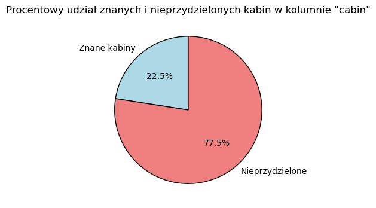

Większość pasażerów nie miała przypisanej kabiny. Możliwe, że kabiny były przypisywane głównie pasażerom 1 klasy.

Kabiny miały oznaczenia literowe, które wskazują na ich lokalizację. Możemy sprawdzić, jak kabiny były rozmieszczone według klasy pasażerskiej.

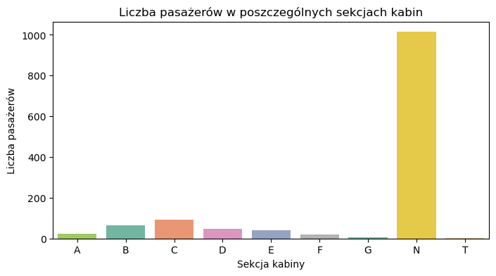

Kabiny oznaczone literami (np. A, B, C...) wskazują lokalizację na statku, a dokładniej litera oznacza pokład, na którym znajdowała się kabina.

A – Najwyższy pokład (Boat Deck), luksusowe apartamenty 1 klasy.

B, C – Kabiny 1 klasy, położone na wyższych pokładach.

D, E – Kabiny 1 i 2 klasy (D bardziej luksusowe, E mniej).

F – Kabiny głównie 2 klasy, chociaż część F mogła należeć do 3 klasy.

G- Dolny pokład, głównie 2 klasa, ale w pobliżu maszynowni mogły znajdować się kabiny dla pasażerów 3 klasy.

T – W danych Titanica pojawia się jedna kabina oznaczona "T", ale brak historycznych dowodów, że taka sekcja istniała. Najprawdopodobniej jest to błąd w dokumentacji lub omyłkowe przypisanie. Statek nie miał pokładu oznaczonego "T" – litery kończyły się na "G".

N - Pasażerowie 3 klasy często nie mieli przypisanych indywidualnych kabin, ale spali w większych pomieszczeniach wieloosobowych.

```
Liczba pasażerów przypisanych do poszczególnych sekcji kabin (na podstawie pierwszej litery kodu kabiny):

cabin_section
N    1014
C      94
B      65
D      46
E      41
A      22
F      21
G       5
T       1
Name: count, dtype: int64
```

W niektórych przypadkach kilka osób mogło dzielić jedną kabinę (np. rodziny). Możemy zobaczyć, ile osób było przypisanych do tych samych kabin.

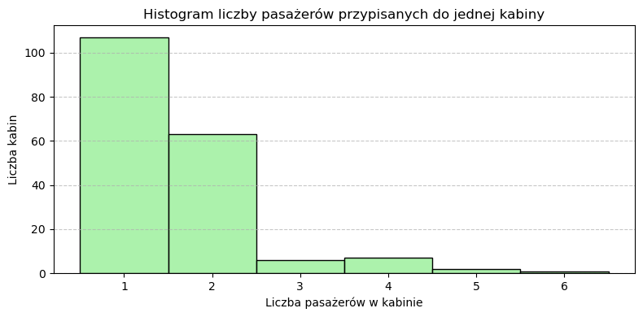

Pasażerowie 2 i 3 klasy często dzielili kabiny z innymi osobami. Klasy były mniej kosztowne, a pasażerowie mogli dzielić przestrzeń z innymi.

### Cena biletu (fare)

```
count    1309.000000
mean       33.281086
std        51.741500
min         0.000000
25%         7.895800
50%        14.454200
75%        31.275000
max       512.329200
Name: fare, dtype: float64
```

```
Średnia cena biletu wynosiła 33.0 funty
Cena najtańszego biletu to 0.0 funtów
Najdroższy bilet kosztował 512.3292 funtów
```

Cena minimalna wynosi 0 zł co wydaje się być niemożliwe, prawdopodobnie oznacza to, że część pasażerów podróżowała na specjalnych warunkach, np. jako załoga lub pasażerowie na zniżkach.

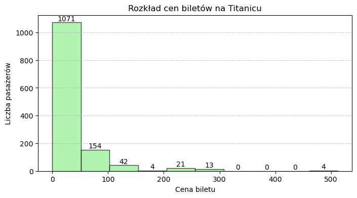

Rozkład cen jest bardzo niesymetryczny.

Większość pasażerów kupowała bilety w niskim przedziale cenowym (blisko 0–50 funtów), co sugeruje, że większość osób podróżowała w 3 klasie. Tylko czterech pasażerów zapłaciło bardzo wysokie ceny za bilety w luksusowych kabinach pierwszej klasy.

|  | pclass | fare |
| --- | --- | --- |
| 0 | 1.0 | 87.508992 |
| 1 | 2.0 | 21.179196 |
| 2 | 3.0 | 13.304513 |

Ogromna różnica w cenach między klasami

Średnia cena biletu w 1 klasie (87.51) jest ponad 4 razy wyższa niż w 2 klasie (21.18) i ponad 6 razy wyższa niż w 3 klasie (13.30).

Potwierdza to wyraźne różnice w standardzie podróży między klasami.

Klasa pierwsza była luksusowa i dostępna dla najbogatszych, pasażerowie 1 klasy płacili za komfort, przestronne kabiny i lepszą obsługę.

Klasa druga jako opcja pośrednia - średnia cena 21.18 pokazuje, że klasa druga była znacznie tańsza niż pierwsza, ale nadal wyraźnie droższa od trzeciej. Możliwe, że podróżowali nią przedstawiciele klasy średniej – urzędnicy, przedsiębiorcy, lepiej sytuowani rzemieślnicy.

Klasa trzecia – podróż dla mniej zamożnych. Średnia cena 13.30 potwierdza, że 3 klasa była najtańszą opcją, dostępną dla robotników i imigrantów.

Pasażerowie podróżowali w gorszych warunkach, a bilety były znacznie bardziej przystępne cenowo.

Sprawdźmy jeszcze jak wyglada rozkład cen biletów w poszczególnych klasach

| pclass | count | mean | std | min | 25% | 50% | 75% | max |
| --- | --- | --- | --- | --- | --- | --- | --- | --- |
| 1.0 | 323.0 | 87.508992 | 80.447178 | 0.0 | 30.6958 | 60.0000 | 107.6625 | 512.3292 |
| 2.0 | 277.0 | 21.179196 | 13.607122 | 0.0 | 13.0000 | 15.0458 | 26.0000 | 73.5000 |
| 3.0 | 709.0 | 13.304513 | 11.486319 | 0.0 | 7.7500 | 8.0500 | 15.2458 | 69.5500 |

**Pierwsza klasa:**

Średnia cena: 87.51, co wskazuje na stosunkowo wysoką cenę biletów.

Min. cena: 0.0, co może oznaczać darmowe bilety (np. dla załogi) lub specjalne zniżki.

Mediana: 60.00 – cena jest wyraźnie mniejsza niż średnia, co sugeruje, że niektórzy pasażerowie zapłacili bardzo wysokie ceny (np. luksusowe kabiny).

Max. cena: 512.33 – bardzo wysoka cena, co świadczy o istnieniu drogich biletów w 1 klasie, które były przeznaczone dla najbogatszych pasażerów.

**Druga klasa:**

Średnia cena: 21.18, co wskazuje na średni poziom cen, typowy dla klasy średniej.

Min. cena: 0.0, podobnie jak w 1 klasie, możliwe, że niektórzy pasażerowie otrzymali bilety za darmo.

Mediana: 15.05 – średnia cena w tej klasie jest wyższa niż mediana, co wskazuje, że większość pasażerów płaciła ceny nieco poniżej średniej, ale niektóre bilety były droższe.

Max. cena: 73.50 – w tej klasie również występują biletów o wyższych cenach, ale nadal znacznie tańszych niż w 1 klasie.

**Trzecia klasa:**

Średnia cena: 13.30 – cena typowa dla najtańszych biletów, dostępnych dla imigrantów i osób o niższym statusie społecznym.

Min. cena: 0.0 – podobnie jak w innych klasach, być może z powodu biletów za darmo lub symbolicznych opłat.

Mediana: 8.05 – niższa niż średnia, co sugeruje, że duża część pasażerów zapłaciła minimalną cenę za bilet.

Max. cena: 69.55 – najwyższe ceny w 3. klasie są nadal niższe niż te w 2 i 1 klasie, ale wyraźnie wyższe niż większość biletów.

**Wnioski:**

Różnice w cenach między klasami są wyraźne, z największą koncentracją tanich biletów w 3 klasie.

Wysokie ceny biletów w 1. klasie wynikają z luksusowych kabin, a w 2 klasie widać opcje średniej jakości.

Ceny w 3 klasie są głównie niskie, co czyni ją dostępną dla osób mniej zamożnych.

### Port, w którym pasażer wszedł na pokład (embarked)

```
array(['S', 'C', nan, 'Q'], dtype=object)
```

**S** = Southampton (Wielka Brytania)

**C** = Cherbourg (Francja)

**Q** = Queenstown (Irlandia)

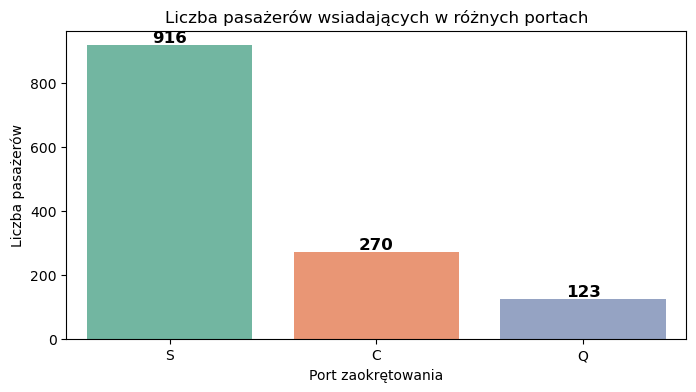

Najwięcej pasażerów wsiadło na pokład w porcie Southampton (S).

Znacznie mniej osób zaokrętowało w Cherbourg (C) i Queenstown (Q).

Port zaokrętowania może mieć wpływ na klasę podróży i prawdopodobieństwo przeżycia, co warto zbadać w dalszej analizie.

### Miejsce docelowe (home.dest)

Określa miejsce docelowe pasażera (np. "New York, NY", "Montreal, Canada").

Pasażerowie podróżowali do wielu różnych miejsc, jednak niektóre destynacje były znacznie popularniejsze. Aby zwiekszyć czytelność danych zawęzimy analizę do 10 najczęściej wybieranych miejsc docelowych.

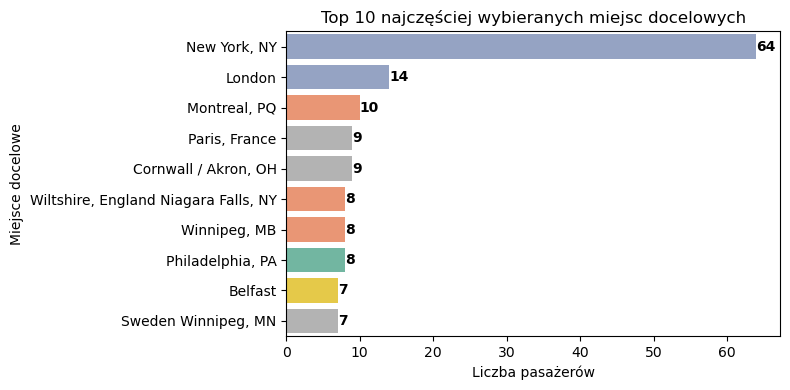

Po zmianie zakresu okazało się, że do najczęściej wybieranych 10 miejsc docelowych zmierzała stosunkowo niewielka liczba pasażerów w porównaniu do całkowitej liczby podróżnych. Oznacza to, że trasa Titanica była wyjątkowo różnorodna biorąc pod uwagę destynację, a wielu pasażerów miało unikalne lub rzadko powtarzające się cele podróży.

```
Liczba wszystkich unikalnych miejscowości docelowych: 370
```

To może sugerować, że Titanic służył nie tylko jako środek transportu do kilku głównych miast, ale również jako łącznik pomiędzy wieloma mniej popularnymi lokalizacjami, do których pasażerowie musieli później kontynuować podróż innymi środkami transportu.

### Numer łodzi ratunkowej (boat)

```
array(['2', '11', nan, '3', '10', 'D', '4', '9', '6', 'B', '8', 'A', '5',
       '7', 'C', '14', '5 9', '13', '1', '15', '5 7', '8 10', '12', '16',
       '13 15 B', 'C D', '15 16', '13 15'], dtype=object)
```

Jeśli pasażer przeżył i został ewakuowany, jego numer łodzi jest podany.

### Numer biletu (ticket)

W zbiorze danych Titanica kolumna ticket zawiera numery biletów pasażerów, np.:

A/5 21171, PC 17599, 113803, STON/O 2. 3101282.

Niektóre bilety miały przedrostki, które mogą wskazywać na:

-- Rodzaj biletu (np. bilet agencyjny, bilet załogi, bilet łączony dla grupy pasażerów).

-- Linię żeglugową lub miejsce zakupu.

Przykłady:

PC Bilet sprzedany przez The Pennsylvania Railroad Company (droższe bilety, głównie 1. klasa).

A/5 Bilet dla emigrantów, głównie 3. klasa.

STON/O „Southampton Office” – bilety kupione w Southampton, często przez emigrantów.

CA Bilet kupiony przez Atlantic Transport Line – klasa 2. i 3.

S.O.C. Bilety wydane przez The White Star Line.

F.C.C. "First Class Cabin" – bilety ekskluzywne, pierwsza klasa.

**Czy numer biletu miał wpływ na przeżycie?**

Ponieważ dostępne dane nie zawierają pełnej informacji na temat struktury numerów biletów oraz ich znaczenia, na potrzeby analizy pominiemy tę zmienną. Zamiast tego skupimy się na miejscu zakwaterowania pasażerów, które może dostarczyć bardziej istotnych informacji na temat ich warunków podróży i potencjalnego wpływu na szanse przeżycia.

# EDA5 - analiza relacji między zmiennymi

Analiza wzajemnych relacji w zbiorze danych ma na celu zrozumienie, w jaki sposób różne cechy pasażerów, takie jak wiek, płeć, klasa pasażerska czy liczba członków rodziny, wpływają na szanse przeżycia. Poprzez badanie korelacji między tymi zmiennymi, będziemy w stanie zidentyfikować czynniki, które miały największy wpływ na przeżycie, a także odkryć potencjalne zależności pomiędzy cechami, które mogą pomóc w dalszym modelowaniu. Przeanalizujmy zatem zależności między cechami a wartością survived.

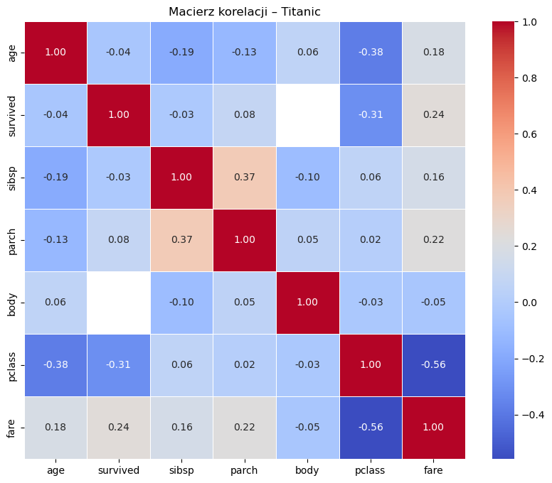

Najsilniejsze ujemne korelacje:

- zmienna klasa biletu koreluje z wiekiem, przeżyciem i ceną biletu,
- sibsp i parch (rodzina na pokładzie) mają dodatnią korelację ze sobą – osoby z rodzeństwem częściej miały też rodziców/dzieci na pokładzie.

Przeanalizujmy zatem zależności między poszczególnymi kategoriami a wartością survived.

### Płeć (sex)

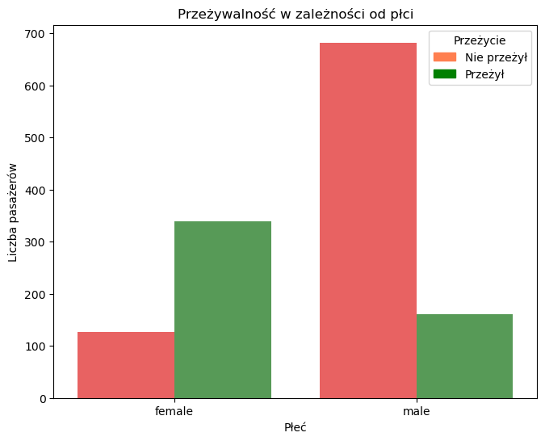

Na wykresie widać wyraźnie, że kobiety miały znacznie wyższe szanse na przeżycie niż mężczyźni. W przypadku kobiet przeważająca liczba pasażerek przeżyła, podczas gdy wśród mężczyzn odsetek tych, którzy nie przeżyli, jest znacznie wyższy.

Skad takie proporcje?

Wśród mężczyzn zaledwie niewielka część przeżyła katastrofę, co wskazuje na bardziej ograniczony dostęp do łodzi ratunkowych.

W przypadku kobiet odsetek przeżycia jest wyraźnie wyższy, co może wynikać z priorytetowego traktowania kobiet i dzieci w procesie ewakuacji.

Sprawdźmy jak to wyglądało procentowo:

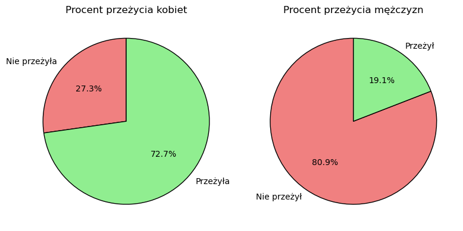

**Podsumowanie:**

Płeć miała istotny wpływ na szanse przeżycia – kobiety miały zdecydowanie wyższy wskaźnik przeżywalności niż mężczyźni.

### Wiek (age)

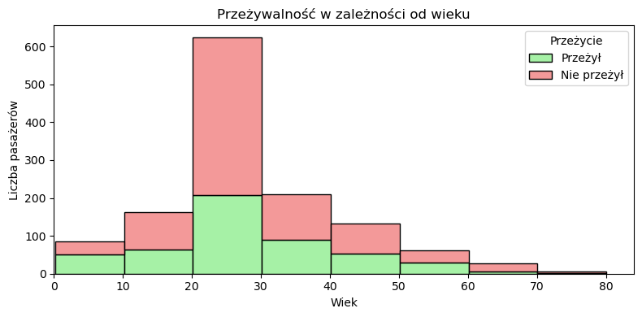

Widać, że młodsze osoby (szczególnie dzieci) miały wyraźnie wyższy wskaźnik przeżycia. Możliwe, że dzieci miały priorytet w ewakuacji, co zwiększało ich szanse na przeżycie.

W przedziale wiekowym 20-40 lat widzimy większą liczbę osób, które nie przeżyły w porównaniu do tych, które przeżyły. Zdecydowana większość osób w tej grupie wiekowej zginęła.

Starsze osoby (powyżej 50 roku życia) miały podobny wskaźnik przeżycia do osób w średnim wieku, ale były mniej liczne w porównaniu do młodszych pasażerów. Widać jednak, że ich szanse na przeżycie były również mniejsze, podobnie jak u dorosłych w średnim wieku. Osoby powyżej 60 roku życia na Titanicu miały znacznie mniejsze szanse na przeżycie w porównaniu do młodszych pasażerów.

**Podsumowanie:**

Możliwe, że priorytet ewakuacyjny dotyczył przede wszystkim dzieci i młodszych pasażerów, co wpłynęło na wyniki przeżywalności w zależności od wieku.

### Tytuł (title)

Aby lepiej zrozumieć wpływ pozycji społecznej i stanu cywilnego na przeżywalność pasażerów Titanica, porównamy odsetki przeżycia wśród osób należących do grupy "Elita", a także między kobietami zamężnymi i niezamężnymi. Taka analiza pozwala dostrzec, czy uprzywilejowane grupy miały realnie wyższe szanse na przetrwanie katastrofy.

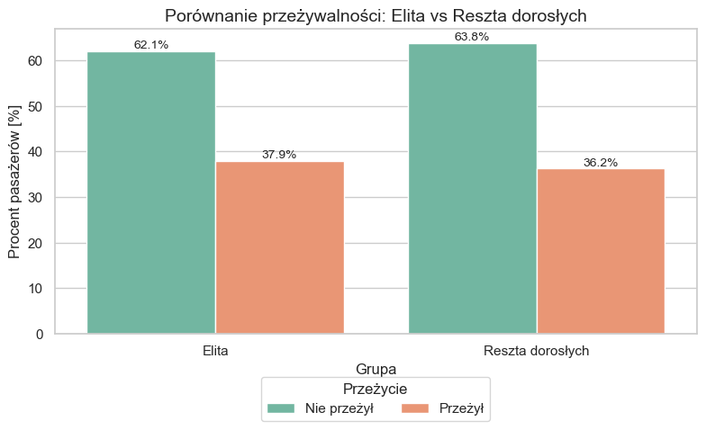

**Wnioski:**

Osoby z tytułem "Elita" (arystokracja, wojskowi, duchowieństwo) miały wyższy procent przeżywalności niż reszta dorosłych pasażerów.

Może to sugerować, że wyższy status społeczny dawał lepszy dostęp do szalup ratunkowych oraz pierwszeństwo w ewakuacji.

Może to również wskazywać na preferencyjne traktowanie pasażerów z wyższym statusem społecznym w krytycznych sytuacjach.

Reszta dorosłych pasażerów (w tym osoby z niższymi tytułami lub bez tytułu) miała niższy procent przeżycia. To może być wynikiem mniejszego priorytetu w ewakuacji, jak również różnic w zdrowiu fizycznym (wielu pasażerów mogło być starszych, chorych lub słabszych fizycznie).

Trzeba jednak podkreślić, że różnice są minimalne.

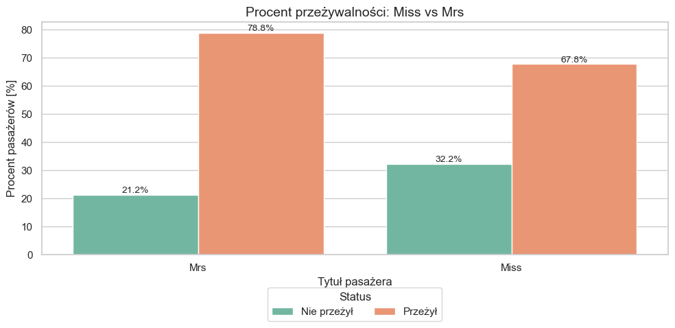

**Wnioski:**

Kobiety zamężne ("Mrs") miały wyższy procent przeżycia w porównaniu do kobiet niezamężnych ("Miss").

Kobiety zamężne mogły mieć lepszy dostęp do szalup ratunkowych dzięki wyższemu statusowi społecznemu (być może były to osoby z klasy średniej lub wyższej). Być może na pierwszeństwo miał wpływ wiek - kobiety zamęże mogły być starsze lub posiadanie dzieci.. Kobiety niezamężne mogły być w większości młodsze mieć większą szansę fizyczną na przeżycie, dlatego nie zawsze były traktowane priorytetowo w ewakuacji.

### Klasa biletu (pclass)

Klasa podróży odzwierciedlała status ekonomiczny pasażerów, co mogło mieć wpływ na dostęp do szalup ratunkowych i pierwszeństwo ewakuacji. Sprawdźmy, jak wyglądała przeżywalność w zależności od klasy: 1 (najwyższa), 2 i 3 (najniższa).

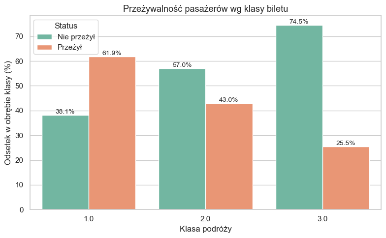

**Wnioski**

Pasażerowie 1 klasy mieli najwyższy odsetek przeżycia – mogli korzystać z pierwszeństwa ewakuacji oraz mieli lepszy dostęp do szalup ratunkowych.

Pasażerowie 2 klasy mieli umiarkowaną przeżywalność, ale wyraźnie niższą niż 1 klasa.

Pasażerowie 3 klasy mieli najniższą szansę na przeżycie, co może wynikać z ich lokalizacji na statku (niższe pokłady), ograniczonego dostępu do wyjść ewakuacyjnych i niższego priorytetu w ewakuacji.

### Liczba rodzeństwa/małżonków na pokładzie, Liczba rodziców/dzieci na pokładzie (sibsp/parch)

Kolejnym z czynników, który mógł wpływać na szanse przeżycia pasażerów Titanica, była obecność członków rodziny na pokładzie. Sprawdzamy, czy osoby podróżujące z rodziną miały wyższy wskaźnik przeżywalności niż pasażerowie podróżujący samotnie.

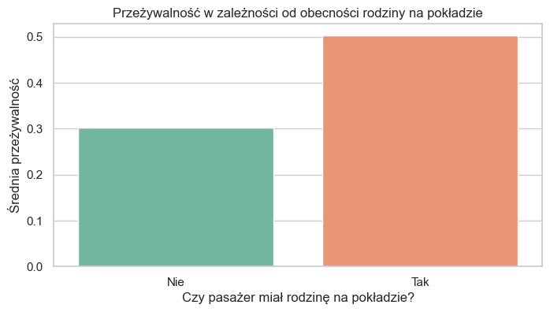

Osoby z rodziną mają średnią przeżywalność ok. 0.5 (50%)

Osoby bez rodziny mają średnią przeżywalność ok 0.3 (30%)

**Wniosek:**

Pasażerowie z rodziną mieli większe szanse na przeżycie. Obecność bliskich mogła wpływać na zachowanie w sytuacji kryzysowej – np. pomagali sobie nawzajem, szybciej podejmowali decyzje, nie byli pozostawieni sami sobie.

Aby dokładniej zrozumieć wpływ obecności rodziny na szanse przeżycia pasażerów Titanica, przeanalizujemy trzy dodatkowe zależności:

1. Jak liczba członków rodziny na pokładzie (czyli suma zmiennych sibsp i parch) wpływała na przeżywalność.
2. Czy efekt obecności rodziny był taki sam dla kobiet i mężczyzn?
3. Czy relacja między podróżowaniem z rodziną a przeżyciem różniła się w zależności od klasy podróży.

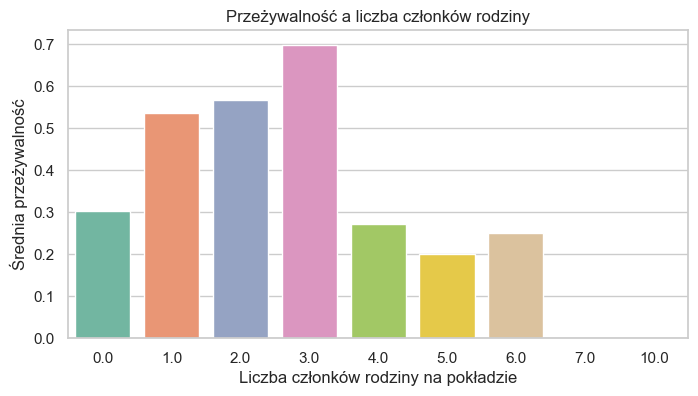

Najwyższa przeżywalność była przy 1–3 członkach rodziny.

Osoby całkowicie samotne (0) i te z bardzo dużą rodziną (5–8) miały niższe szanse.

**Wnioski:**

Zbyt mała lub zbyt duża liczba członków rodziny może zmniejszać szanse przeżycia. Pasażerowie z umiarkowaną liczbą bliskich (1–3) mogli sobie wzajemnie pomagać w bardziej zorganizowany sposób.

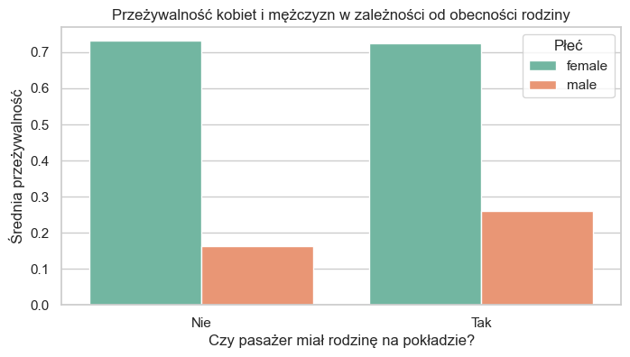

**Wnioski:**

Kobiety mają wysoką przeżywalność niezależnie od obecności rodziny (efekt "kobiety i dzieci najpierw").

Mężczyźni bez rodziny mają najniższą przeżywalność – być może byli zostawieni "na końcu kolejki".

Obecność rodziny miała większy wpływ na szanse przeżycia mężczyzn niż kobiet.

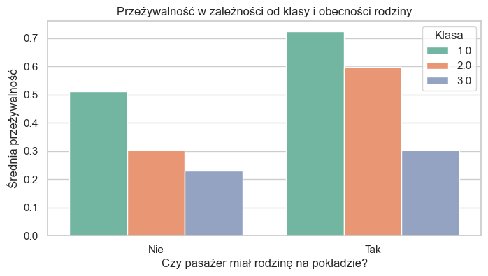

**Wnioski:**

W 1 klasie osoby z rodziną przeżywały najczęściej.

W 3 klasie nawet osoby z rodziną miały niską przeżywalność – trudniejsze warunki ewakuacji?

Obecność rodziny pomagała najbardziej w wyższych klasach, gdzie dostęp do szalup był lepszy.

### Numer kabiny (cabin)

Kabiny na Titanicu oznaczane były literami, które odzwierciedlały położenie na statku — znajdowały się one bliżej górnych pokładów. Sprawdzimy, czy posiadanie takiej kabiny wiązało się z wyższym współczynnikiem przeżycia, oraz czy osoby bez przypisanej kabiny ginęły częściej.

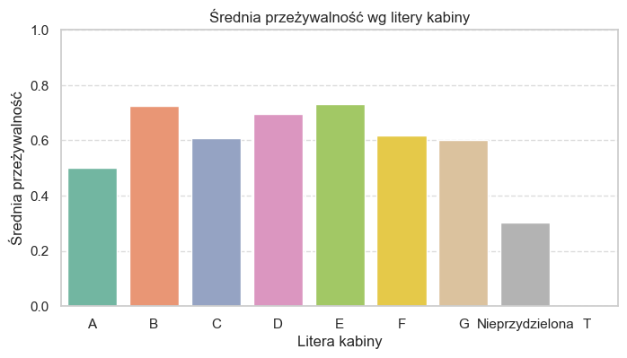

Pasażerowie z kabinami oznaczonymi literami mieli różne wskaźniki przeżycia — przeżywalność pasażerów z kabiny oznaczonej literą B i E była najwyższ (ok. 75%), z kabiny A jednak nieco niższa ok. 50 %), co pokazuje, że nie wszystkie górne pokłady były równe pod względem szans na ratunek.

### Cena biletu (fare)

Cena biletu mogła odzwierciedlać status społeczny oraz klasę podróży pasażera, co mogło wpływać na jego szanse przeżycia. Sprawdzimy czy potwierdzi się hipoteza, że wyższa cena biletu wiązała się z większym prawdopodobieństwem przeżycia katastrofy Titanica.

Najpierw jednak potwierdzimy hipotezę, że cena biletu była zależna od liczby osób na tym samym bilecie Część pasażerów kupowała grupowe bilety (np. rodziny, przyjaciele), co mogło obniżyć koszt biletu na osobę.

Liczba pasażerów wynosiła 1309, liczba wartości unikatowych w kolumnie ticket to 929, co wskazuje na sporą liczbę biletów grupowych.

```
ticket
CA. 2343    11
1601         8
CA 2144      8
PC 17608     7
347077       7
            ..
373450       1
2223         1
350046       1
3101281      1
315082       1
Name: count, Length: 929, dtype: int64
```

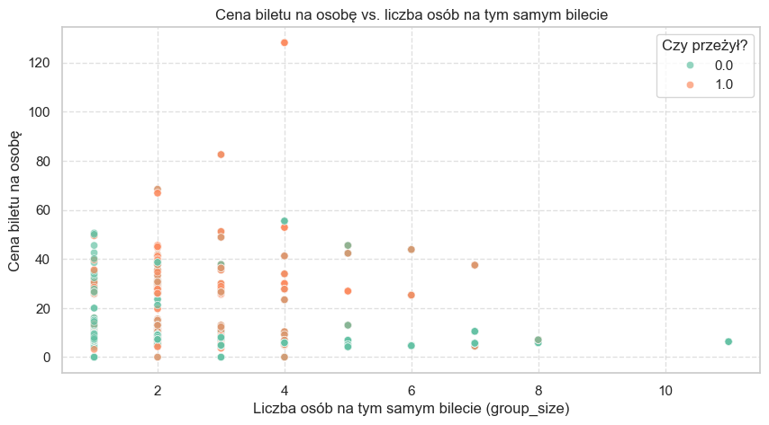

Osoby z tanim biletem grupowym miały niższą przeżywalność — być może ze względu na miejsce w niższych pokładach lub trudniejszy dostęp do pokładów ratunkowych. Widać to zwłaszcza na biletach poniżej 20 funtów oraz grupach powyzej 4 osób.

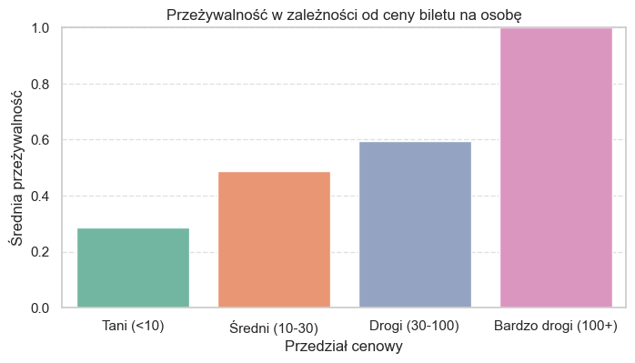

Pasażerowie z najtańszych biletów (<10) mieli najniższą przeżywalność – to byli zapewne pasażerowie 3 klasy, podróżujący w grupach (rodziny, emigranci), z ograniczonym dostępem do pokładów ratunkowych.

W miarę wzrostu ceny biletu (10–30, 30–100), przeżywalność wyraźnie rośnie – co wskazuje, że osoby z wyższych klas miały większe szanse na przeżycie.

Najdroższe bilety (>100) wiążą się z najwyższą przeżywalnością, ale należy pamiętać, że w tej grupie było stosunkowo mało osób – więc średnia przeżywalność może nie oddawać ogólnej tendencji i być bardziej przypadkowa.

**Wnioski:**

Droższe bilety (na osobę) zwiększały szansę na przeżycie – co może sugerować, że pasażerowie z wyższych klas mieli lepszy dostęp do szalup ratunkowych.

Cena biletu na osobę maleje, gdy więcej osób korzysta z tego samego biletu – sugeruje to bilety grupowe (rodziny, przyjaciele), które były tańsze w przeliczeniu na jedną osobę. Osoby z tanim biletem grupowym miały niższą przeżywalność — być może ze względu na miejsce w niższych pokładach lub trudniejszy dostęp do pokładów ratunkowych.

### Port, w którym pasażer wszedł na pokład (embarked)

Port zaokrętowania wskazuje miejsce, z którego pasażer wsiadł na pokład Titanica. Trzy główne porty to: Cherbourg (C), Queenstown (Q) i Southampton (S). Możemy sprawdzić, czy port miał związek z szansą na przeżycie, oraz czy był powiązany z klasą biletu.

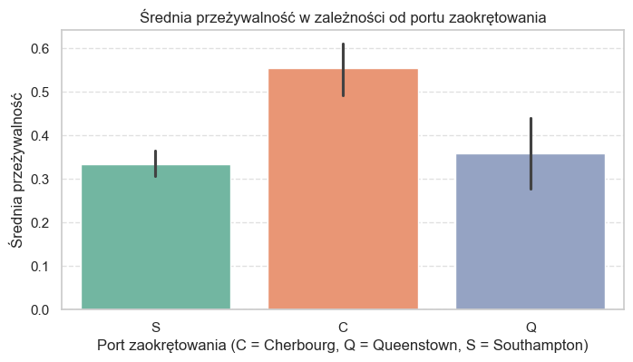

Te czarne pionowe kreski nad słupkami na wykresie to przedziały ufności. Pokazują niepewność estymacji średniej przeżywalności dla każdej kategorii (czyli portu). Innymi słowy wskazują zakres, w którym z 95% pewnością znajduje się prawdziwa średnia przeżywalność w danej grupie.

Im krótsza kreska, tym bardziej pewny i stabilny jest wynik (dużo obserwacji, mała zmienność).

Im dłuższa – tym mniejsza liczba danych lub większa zmienność → mniej pewna średnia.

Pasażerowie z Cherbourga mieli wyraźnie najwyższą przeżywalność.

Southampton (S) było głównym portem załadunku, ale pasażerowie stamtąd mieli najniższą przeżywalność.

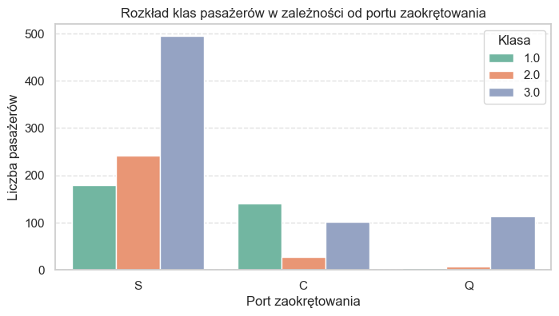

W Cherbourgu (C) dominowali pasażerowie 1 klasy, co wyjaśnia wysoką przeżywalność.

W Southampton (S) wsiadło najwięcej pasażerów, głównie z klasy 3, co tłumaczy niższą przeżywalność.

Port Queenstown (Q) obsługiwał przede wszystkim klasę 3 – wielu pasażerów z Irlandii i emigrantów.